# Understanding forest loss in different tropical forest ecosystem

Mo Chen_r11241202, Ethan Wang_r11241204

2022-12-30

### Introduction

Tropical forests are terrestrial biodiversity hotspots, since the strata they form creates different ecological niches for organisms to live in. Tropical forests plays important role in regulating climate, not only because their ability absorbing carbon dioxide, they also manipulates water globally. In fact, in South America, the amount of water that moves inland from the sky of ocean are even more than Amazon river pumps into the ocean, therefore it is important to protect tropical forest. To achieve this goal, understanding what makes tropical forest loss become crucial, with advance satellite technology and helps from volunteers, a group of scientist finally establish a dataset that provides information about deforestation in global. In our work, we try to examine what is the main driver of forest loss in different tropical forest region, and hope to have a better understand about them.

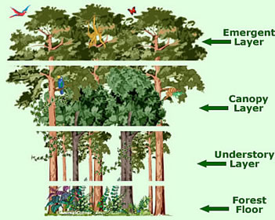

strata, https://animalcorner.org/rainforests/canopy-layers/

Here is a little video about the water flow in the sky of amazon tropical forest.

- [The Largest River On Earth Is In The Sky](https://www.youtube.com/watch?v=VGurBZ0b6nI)

Chunk below are the tools we used in this dataset

```r
library(ggplot2)
library(ggmap)
library(rnaturalearth)
library(tidyverse)
library(forcats)
library(vegan)
library(RColorBrewer)
library(ade4)
library(factoextra)
library(magrittr)
library(sp)
library(rworldmap)
library(leaflet)
```

### Data input and arrangement

In our project, we use the data from “Drivers of tropical forest loss between 2008 and 2019”, and only used the control data since our computers aren’t capable of such massive dataset. In this part, we manipulates the data so that we can remove the question part that isn’t part of the data result and also combine the predominant drivers and secondary drivers of same data point together, thus made this dataset easier to use.

```r
#read the dataset % manipulate it
control <- read.csv("D:/R_WD/Git linked/2022RisFUN-Mo/Final present/Data_fp/ILUC_DARE_controls_x_y.csv")
control <- control%>%arrange(answer)
control_pivot <- control%>%pivot_wider(id_cols = c(sampleid,x,y),
                                       names_from = step,values_from = answer,
                                       values_fn = function(x)paste(x,collapse = ","))
control_pivot <- rename(control_pivot, architecture=step3,predominant.driver=step1,other.drivers=step2)
```

#### Quick view of the dataset

Next, we make several maps to have a quick view about global forest loss in world wide and different tropical forest region. In the end we didn’t chose the leaflet function, because we try to focus on three different tropical forest regions, namely: America, Africa and Aisa & Oceania.

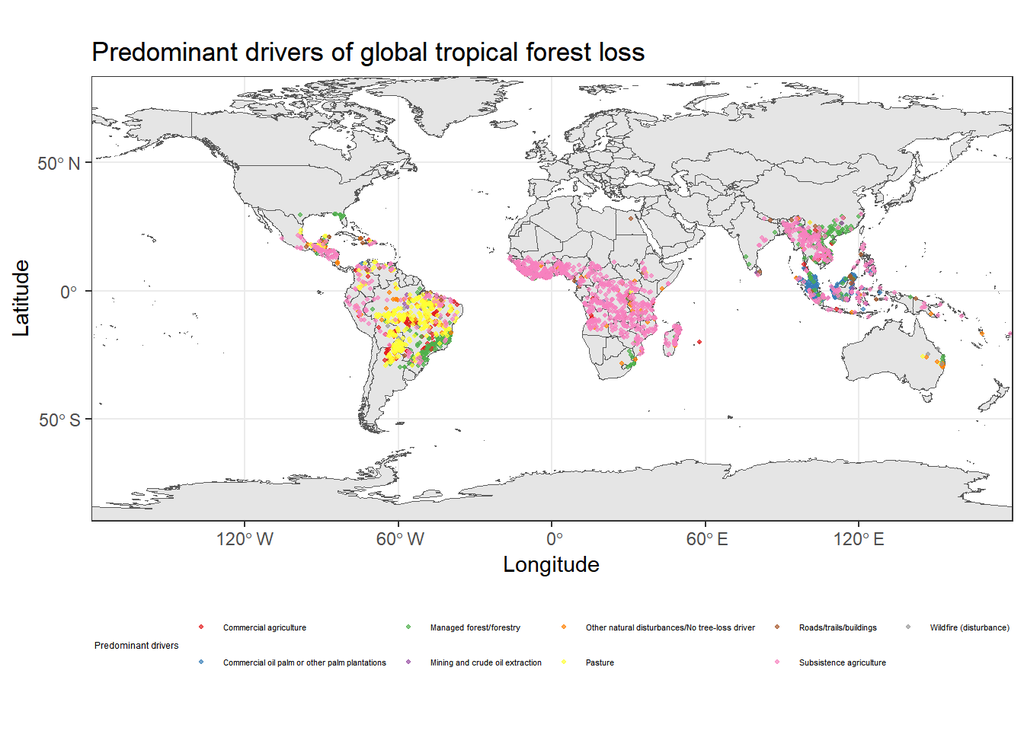

```r
# make the plots
world <- ne_countries(scale = "medium", returnclass = "sf")
predominant.driver <- ggplot(data=world)+
  geom_sf()+
  coord_sf(expand=F)+
  labs(x="Longitude",y="Latitude")+
  geom_point(data=control_pivot,aes(x=x,y=y,colour=factor(predominant.driver)),
             alpha=0.7,size=0.7)+
  ggtitle("Predominant drivers of global tropical forest loss")+
  scale_color_brewer(name="Predominant drivers",palette= "Set1")+
  theme_bw()+
  theme(legend.position = "bottom",
        legend.title = element_text(size = 4.5),
        legend.text = element_text(size=4))
predominant.driver #the distribution of predominant driver of global forest loss
```

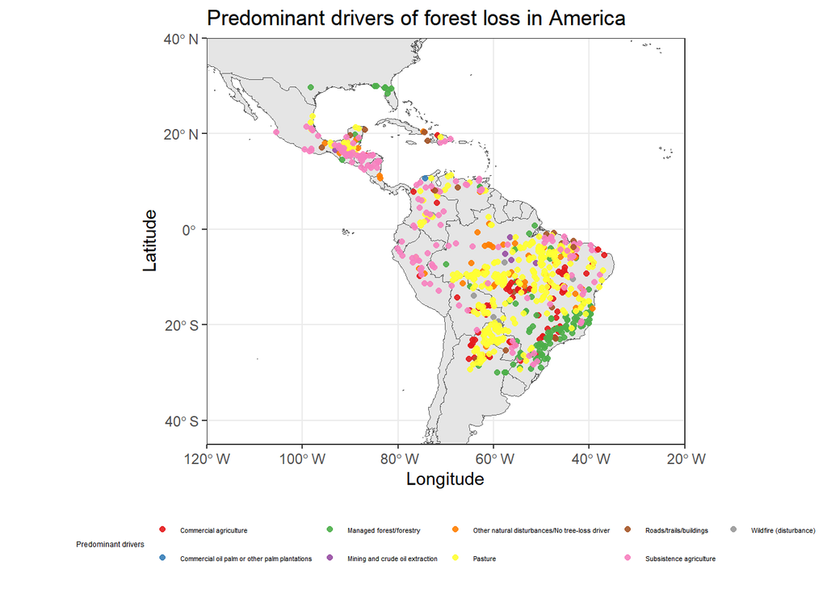

```r
SAmerica.predominant.plot <- ggplot(data=world)+  #America
  geom_sf()+
  coord_sf(xlim=c(-120,-20),ylim=c(-45,40),expand=F)+
  labs(x="Longitude",y="Latitude")+
  geom_point(data=control_pivot,aes(x=x,y=y,colour=factor(predominant.driver)),
             alpha=0.9)+
  ggtitle("Predominant drivers of forest loss in America")+
  scale_color_brewer(name="Predominant drivers",palette= "Set1")+
  theme_bw()+
  theme(legend.position = "bottom",
        legend.title = element_text(size = 4.5),
        legend.text = element_text(size=4))
SAmerica.predominant.plot #the distribution of predominant forest loss driver in South America
```

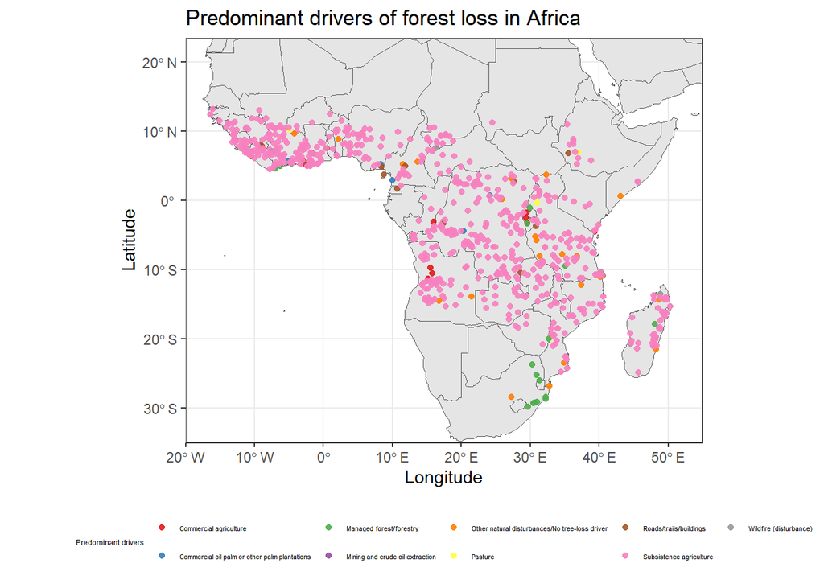

```r
Africa.predominant.plot <- ggplot(data=world)+  #Africa
  geom_sf()+
  coord_sf(xlim=c(-20,55),ylim=c(-35,23.5),expand=F)+
  labs(x="Longitude",y="Latitude")+
  geom_point(data=control_pivot,aes(x=x,y=y,colour=factor(predominant.driver)),
             alpha=0.9)+
  ggtitle("Predominant drivers of forest loss in Africa")+
  scale_color_brewer(name="Predominant drivers",palette= "Set1")+
  theme_bw()+
  theme(legend.position = "bottom",
        legend.title = element_text(size = 4.5),
        legend.text = element_text(size=4))
Africa.predominant.plot #the distribution of predominant forest loss driver in Africa
```

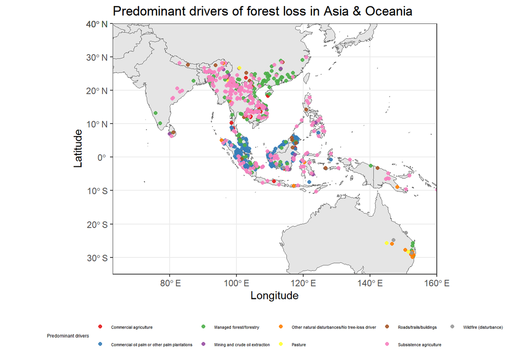

```r
AO.predominant.plot <- ggplot(data=world)+  #Asia
  geom_sf()+
  coord_sf(xlim=c(63,160),ylim=c(-35,40),expand=F)+
  labs(x="Longitude",y="Latitude")+
  geom_point(data=control_pivot,aes(x=x,y=y,colour=factor(predominant.driver)),
             alpha=0.9)+
  ggtitle("Predominant drivers of forest loss in Asia & Oceania")+
  scale_color_brewer(name="Predominant drivers",palette= "Set1")+
  theme_bw()+
  theme(legend.position = "bottom",
        legend.title = element_text(size = 4.5),
        legend.text = element_text(size=4))
AO.predominant.plot #the distribution of predominant forest loss driver in South Asia and Oceania
```

#### Visulation by percentage of forest loss

In order to visualize the composition of forest loss in different region, we use bar plot to examine them, and also have a stacked bar plot for us to compare.

```r
#define dataset into South America, Africa and Asia/Oceania to make barplot
Am_bar <- filter(control_pivot, x<=-20 & x>=-120 & y<=40 & y>=-45)
Af_bar <- filter(control_pivot, x<=55 & x>=-20 & y<=23.5 & y>=-35)
AO_bar <- filter(control_pivot, x<=160 & x>=63 & y<=40 & y>=-35)
```

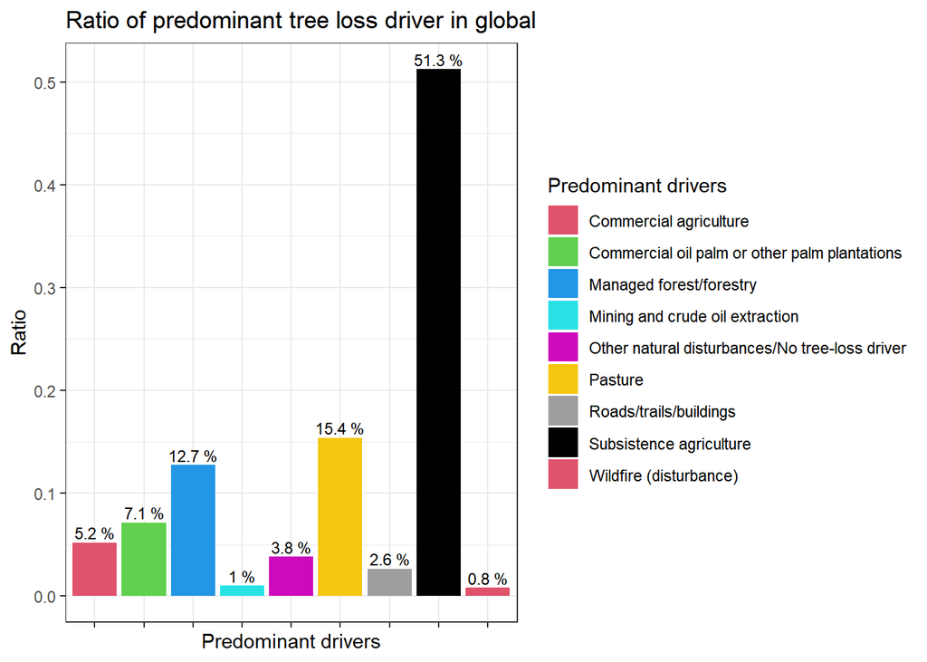

```r
#percentage of predominant drivers in global
predominant.driver <- fct_count(factor(control_pivot$predominant.driver),sort = T)
predominant.driver$ratio <- predominant.driver$n/sum(predominant.driver$n)
ratio.pre.driver <- ggplot(data = predominant.driver, aes(x=f,y=ratio,fill=f))+
  geom_bar(stat = "identity")+
  scale_fill_manual(name="Predominant drivers",values= c(2:10))+
  geom_text(aes(label=paste(100*round(ratio,3),"%")),vjust=-0.3,size=3)+
  theme_bw()+
  theme(axis.text.x = element_blank())+
  ggtitle("Ratio of predominant tree loss driver in global")+
  labs(x="Predominant drivers",y="Ratio")
ratio.pre.driver #the barplot of predominant drivers in global
```

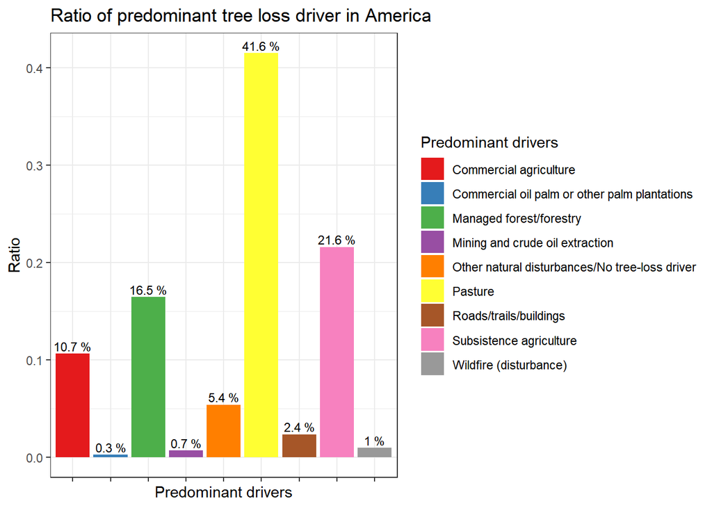

```r
#percentage of predominant drivers in South America
predominant.drivers.SAmerica <- fct_count(factor(Am_bar$predominant.driver),sort = T)
predominant.drivers.SAmerica$ratio <- predominant.drivers.SAmerica$n/sum(predominant.drivers.SAmerica$n)
ratio.pre.driver.sAmerica <- ggplot(data = predominant.drivers.SAmerica, aes(x=f,y=ratio,fill=f))+
  geom_bar(stat = "identity")+
  scale_fill_brewer(name="Predominant drivers",palette = "Set1")+
  geom_text(aes(label=paste(100*round(ratio,3),"%")),vjust=-0.3,size=3)+
  theme_bw()+
  theme(axis.text.x = element_blank())+
  ggtitle("Ratio of predominant tree loss driver in America")+
  labs(x="Predominant drivers",y="Ratio")
ratio.pre.driver.sAmerica #the barplot of predomiant drivers in South America
```

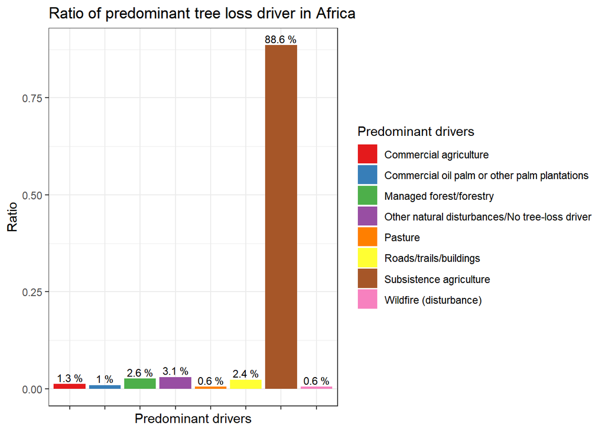

```r
#percentage of predominant drivers in Aferica
predominant.drivers.Africa <- fct_count(factor(Af_bar$predominant.driver),sort = T)
predominant.drivers.Africa$ratio <- predominant.drivers.Africa$n/sum(predominant.drivers.Africa$n)
ratio.pre.drivers.Africa <- ggplot(data = predominant.drivers.Africa, aes(x=f,y=ratio,fill=f))+
  geom_bar(stat = "identity")+
  scale_fill_brewer(name="Predominant drivers",palette = "Set1")+
  geom_text(aes(label=paste(100*round(ratio,3),"%")),vjust=-0.3,size=3)+
  theme_bw()+
  theme(axis.text.x = element_blank())+
  ggtitle("Ratio of predominant tree loss driver in Africa")+
  labs(x="Predominant drivers",y="Ratio")
ratio.pre.drivers.Africa #the barplot of predominant drivers in Aferica
```

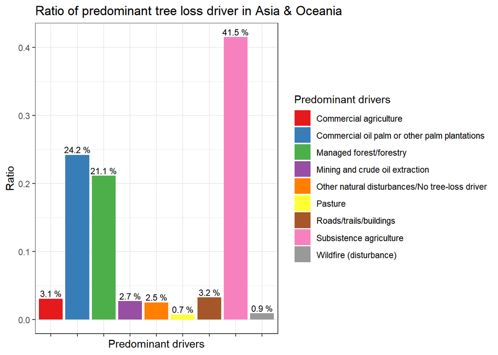

```r
#percentage of predominant drivers in Asia/Oceania
predominant.drivers.Asia <- fct_count(factor(AO_bar$predominant.driver),sort = T)
predominant.drivers.Asia$ratio <- predominant.drivers.Asia$n/sum(predominant.drivers.Asia$n)
ratio.pre.drivers.Asia <- ggplot(data = predominant.drivers.Asia, aes(x=f,y=ratio,fill=f))+
  geom_bar(stat = "identity")+
  scale_fill_brewer(name="Predominant drivers",palette = "Set1")+
  geom_text(aes(label=paste(100*round(ratio,3),"%")),vjust=-0.3,size=3)+
  theme_bw()+
  theme(axis.text.x = element_blank())+
  ggtitle("Ratio of predominant tree loss driver in Asia & Oceania")+
  labs(x="Predominant drivers",y="Ratio")
ratio.pre.drivers.Asia #the barplot of predominant drivers in Asia/Oceania
```

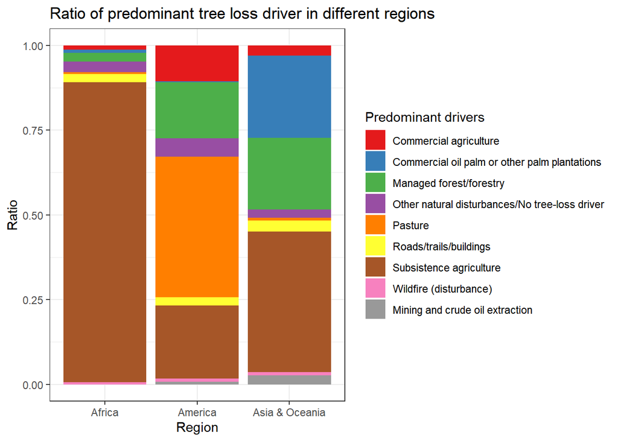

```r
Af_assign <- predominant.drivers.Africa %>% add_column(region = "Africa")
Am_assign <- predominant.drivers.SAmerica %>% add_column(region = "America")
AO_assign <- predominant.drivers.Asia %>% add_column(region = "Asia & Oceania")

Assgin_merged <- bind_rows(Af_assign, Am_assign, AO_assign)

Ratio_region <- NULL
Ratio_region <- ggplot(data = Assgin_merged,aes(x=region,y=ratio,fill=f))+
  geom_bar(position = "fill", stat = "identity")+
              scale_fill_brewer(name="Predominant drivers",palette = "Set1")+
              theme_bw()+
              ggtitle("Ratio of predominant tree loss driver in different regions")+
              labs(x="Region",y="Ratio")
Ratio_region
```

### Data analysis and result

Here we further assign data point to countries where it belongs to, and transform the drivers into matrix form so we can evaluate the difference instead of just visualizing them.

```r
#categorize dataset into three continents
control_pivot$region <- ifelse(control_pivot$x>=-120 & control_pivot$x<=-20,"America",
                               ifelse(control_pivot$x>=-20 & control_pivot$x<=60,"Africa","Asia & Oceania"))

countries <- function(points) #this function is used to categorize dataset into different countries
{
  countriesSP <- getMap(resolution='low')
  pointsSP = SpatialPoints(points, proj4string=CRS(proj4string(countriesSP)))
  indices = over(pointsSP, countriesSP)
  indices$ADMIN  #returns country name
}
#categorize data into countries they are located
points <- data.frame(lon=control_pivot$x,lat=control_pivot$y)#the longitude and latitude of data
control_pivot$country <- countries(points) #use "countries" function
```

```r
#transform control_pivot dataframe to presence absence matrix by predominant drivers
presence.pre.drivers <- control_pivot%>% #presence absence matrix
  mutate(presence=1)%>%
  pivot_wider(id_cols = c(sampleid,x,y,region,country),names_from = predominant.driver,values_from = presence)
presence.pre.drivers[,-(1:5)] <-ifelse(is.na(presence.pre.drivers[,-(1:5)]),0,1) #1= presence, 0=absence
```

#### PCA analysis of forest loss drivers in three tropical forest regions

We want to know which drivers can let us distinguish one region from others, to assess which driver impacts the most, we use PCA analysis to analyze them. After analysis, we found that subsistence agriculture cause the most forest loss in Africa region, but they seems have much overlapping in three different regions, so we try to analyze them from country level.

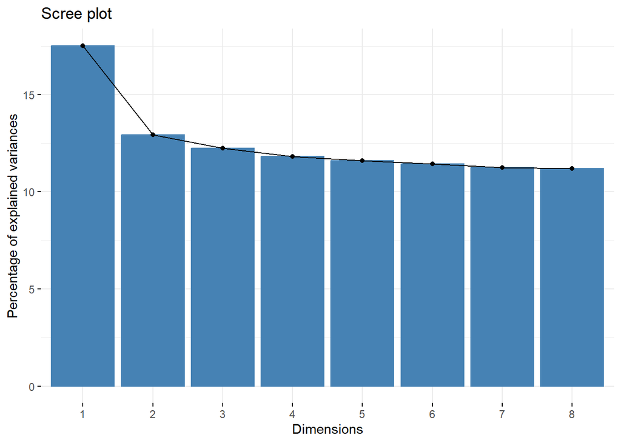

```r
#not categorize into countries, just the lon & lat of data
predominant.pca2 <- dudi.pca(presence.pre.drivers[-(1:5)],
                             scannf=F,nf=6,scale = T)
fviz_eig(predominant.pca2)
```

```r
get_eig(predominant.pca2)
```

```
##       eigenvalue variance.percent cumulative.variance.percent
## Dim.1   1.576899         17.52110                    17.52110
## Dim.2   1.163828         12.93143                    30.45252
## Dim.3   1.101005         12.23339                    42.68591
## Dim.4   1.063469         11.81633                    54.50224
## Dim.5   1.044273         11.60303                    66.10527
## Dim.6   1.030029         11.44477                    77.55004
## Dim.7   1.011864         11.24293                    88.79297
## Dim.8   1.008633         11.20703                   100.00000
```

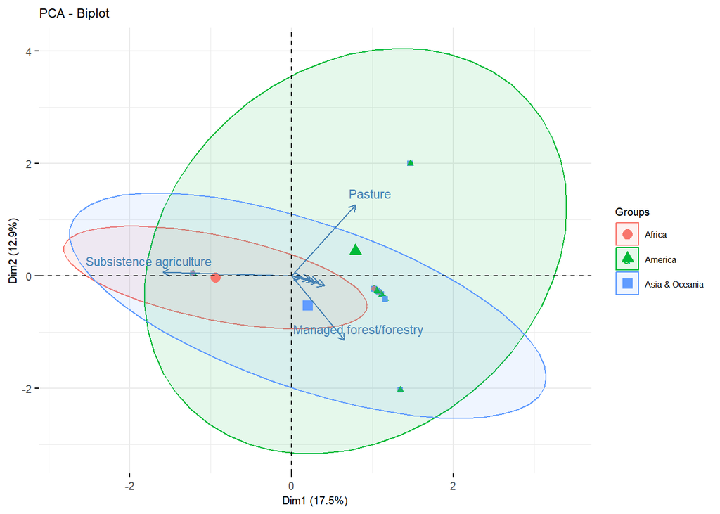

```r
fviz_pca_biplot(predominant.pca2,repel = T,habillage=control_pivot$region,
                alpha.ind=0.5,addEllipses = T,ellipse.level=0.95,
                labelsize=3)+
  theme(text = element_text(size = 7.5),
        axis.title = element_text(size = 7.5),
        axis.text = element_text(size = 7.5))
```

When analyzing at country level, there seems have differences among three regions. Asia & Oceania has more forest loss because of oil palm plantation, and America have more in pasture. Africa may looks much gathered in the middle area, but we can still tell that there’s much difference when compare to two other region.

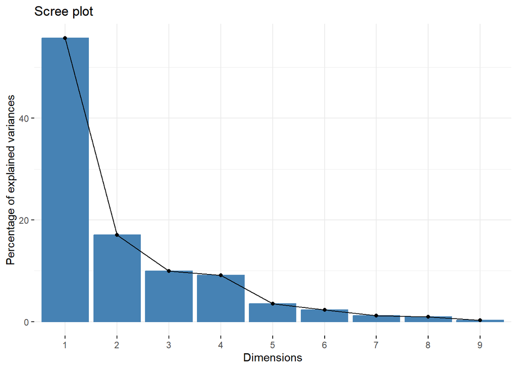

```r
#categorize into countries
presence.pre.drivers.na.omit <- presence.pre.drivers%>%na.omit(country) #there are some data categorized into NA because we cannot find what countries they are located in.
#because there are only 8 NA data, we exclude them from the data set
presence.pre.drivers.countries <- presence.pre.drivers.na.omit%>% #after categorizing them into countries, the numbers of predominant drivers in each country are summed up
  group_by(country)%>%
  summarise(across("Pasture":"Mining and crude oil extraction",.fns=sum))

countries.continent <- control_pivot%>% #the table of the countries and the continents they are located in
  select(country,region)%>%
  unique()%>%
  na.omit()%>%
  arrange(country)

#use country as unit to conduct PCA
predominant.pca <- dudi.pca(presence.pre.drivers.countries[,-1],
                             scannf=F,nf=9,scale = T)
fviz_eig(predominant.pca)
```

```r
get_eig(predominant.pca)
```

```
##       eigenvalue variance.percent cumulative.variance.percent
## Dim.1 5.01817748       55.7575275                    55.75753
## Dim.2 1.53104464       17.0116071                    72.76913
## Dim.3 0.89122257        9.9024729                    82.67161
## Dim.4 0.81684742        9.0760825                    91.74769
## Dim.5 0.31556041        3.5062268                    95.25392
## Dim.6 0.20829598        2.3143998                    97.56832
## Dim.7 0.10868590        1.2076212                    98.77594
## Dim.8 0.08355439        0.9283821                    99.70432
## Dim.9 0.02661121        0.2956801                   100.00000
```

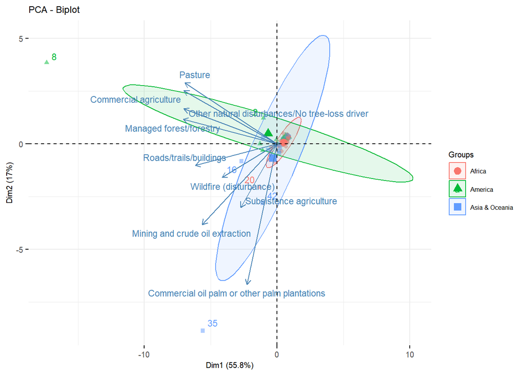

```r
fviz_pca_biplot(predominant.pca,repel = T,
                alpha.ind=0.5,
                labelsize=3,habillage = countries.continent$region, #group them into three continents
                addEllipses = T,ellipse.level=0.95)+
  theme(text = element_text(size = 7.5),
        axis.title = element_text(size = 7.5),
        axis.text = element_text(size = 7.5))
```

### Conclusion

As the distribution maps and barplots show, we can observe that the most predominant forest loss driver in global is subsistence agriculture which accounts for half of forest loss drivers in global. Divided into three continents, the forest loss in Africa is almost due to subsistence agriculture, whereas there are more drivers responsible for forest loss in South America and Asia/Oceania, which is dominated by pasture and subsistence agriculture, respectively. In South America, the top three drivers are pasture, subsistence agriculture and managed forestry, while in Asia/Oceania those drivers are subsistence agriculture, commercial oil palm and managed forestry. Similar with the conclusions from barplots, the analysis of PCA shows that data in three continents cannot be separated clearly, however there is more different between South America and Africa and Asia/Oceania. The PCA plot indicates that drivers in America are dominated by pasture, commercial agriculture and managed forestry, while those in Africa and Asia/Oceania are controled by subsistence agriculture, commercial oil palm and mining.

### Reference:

Fritz, S., Laso Bayas, J. C., See, L., Schepaschenko, D., Hofhansl, F., Jung, M., . . . McCallum, I. (2022). A Continental Assessment of the Drivers of Tropical Deforestation With a Focus on Protected Areas. Frontiers in Conservation Science, 3. https://doi.org/10.3389/fcosc.2022.830248

Laso Bayas, J. C., See, L., Georgieva, I., Schepaschenko, D., Danylo, O., Durauer, M., . . . Fritz, S. (2022). Drivers of tropical forest loss between 2008 and 2019. Sci Data, 9(1), 146. https://doi.org/10.1038/s41597-022-01227-3

Stibig, H. J., Achard, F., Carboni, S., Raši, R., & Miettinen, J. (2014). Change in tropical forest cover of Southeast Asia from 1990 to 2010. Biogeosciences, 11(2), 247-258. https://doi.org/10.5194/bg-11-247-2014